# 1-IntroToMachineLearningInPythonSciKitLearn_CategoricalAndNumericData slides

[figure not shown]

```python
from IPython.display import Image
Image("../src/photos/machine_learning_joke.png",width=600)
```

### What is machine learning

The term machine learning was first defined by Arthur Samuel in 1959 as follows:

> Machine learning is the field of study that gives computers the ability to learn without being explicitly programmed.

Based on that definition, he developed what later became known as the *Samuel's checkers- player algorithm* whose purpose was to choose the next move based on a number of factors

> ... machine learning focuses on the study of algorithms that help improve the performance of a given task through experience...

*What You Need to Know About Machne Learning*

## Important concepts in machine learning

- To effectively use machine learning, start with a question in mind

  > Analyzing the associated data with the help of a trained machine, Allows you to take informed decisions based on the predictions and classifications provided by it.

> Machine learning does not free you from taking actions but gives you the necessary information to ensure those actions are properly supported

## Machine Learning Uses

1. Prediction
2. Classification
3. What-If Analysis

#### Use cases and scikit-learn

- machine learning is an algorithm that can learn from data
- use ex:
  - spam hunting;
  - image recogniition
  - object representation;

#### 4 main categories:

1. *Classification* ID a thing,
2. *Regression* predict a thing,
3. *Clustering* finds patterns in the data itself;
4. *Rule-Extraction* Recommendations

## Types of Learning

1. Supervised
2. Unsupervised
3. Reinforcement Learning

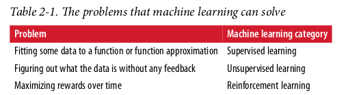

```python
Image('../src/photos/thoughtfulML_ml_Problems2Solve.png',width=800)
```

## Supervsed Learning

- a.k.a Function Approximation
- fitting data to a function of any form.
- Supervised learning models are pre_labeled to help correct the model

## Unsupervised Learning

- Unsupervised learning models are non-labled models; only have the data; structures are found; no *Y* variables; no corpus; no training phase
- figuring out what makes the data special

## Reinforcement Learning

- Multistage games with rewards and payoffs
- Iterated Prisoner's Dilemma

## Limits and Bounds: How Far can the Models Go

Machine leaning models are both simple and complex representations of phenomina we experience in the world.

Each have their own trade-offs associated with them

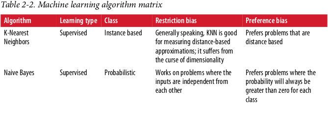

```python
Image('../src/photos/thoughtfulML_mlAlgo_matrix1.png',width=800)
```

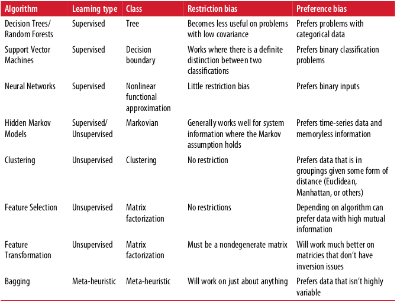

```python
Image("../src/photos/thoughtfulML_mlAlgo_matrix2.png",width=800)
```

## The Trade-Off Between Model Flexibility and Model Interpretability

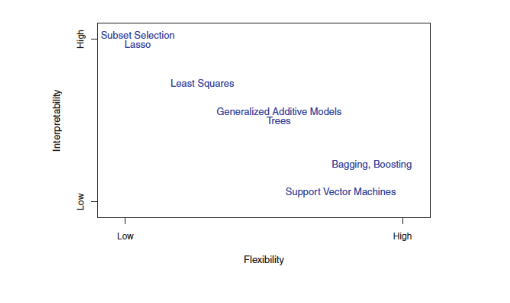

```python
Image("../src/photos/flexibility_interop_tradeoff.png",width=1000)
```

### Training and Test Set

- Training set - data used for building/training the machine learning model.
- Test set - data used for checking the performance of the model built using training set.

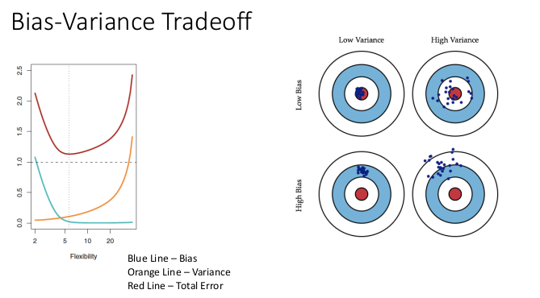

```python
Image("../src/photos/bias_variance_tradeoff.png",width=800)
```

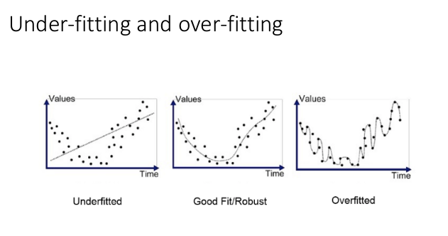

```python
Image("../src/photos/under_vs_overfitted.png")
```

### Data and Dimension Reduction

- The performance of machine learning algorithm can be improved when the number of variable is limited
- When large number of records can be grouped into homogeneous group.
- Data Reduction - consolidating a large number of records into a smaller set
- Dimension Reduction - Reducing number of variable
  - Dimension reduction is a common step before applying supervised learning methods to improve their predictive power.

[figure not shown]

```python
Image("../src/photos/box_i_sits.png",width=600)
```

## Math In Machine Learning

- Machine Learning Models are inherently complex in their modern form
- The math behind all of them boils down to a few simple things

> Most people assume a *Statistician* is somewhere between an accountant and a wizard; This is untrue, we have nothing in common with accountants.

```
                                        Dr. Kristin Lennox
```

#### Continuos Data vs. Categorical Data

- Continuous -> infiitue set of values -> needs basic high school maths
- Categorical -> finite set of variables; just two variables *binary variables*
- *Feature Vector* -> thing fed into the model;
- *Label* -> model output
- *Representation* -> based systems look for their own features; Deep Learning models like neural networks;

## Central Tendency Measures:

### Mean

- the mean is the average of the points; it's a single number representing all the points and dividing by the total number

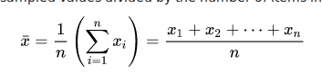

```python
Image("../src/photos/arithmetic_mean.png")
```

### Variation

- Do the numbers jump around; and by how much?
- variance is the sum of the squared distance of the points from the mean, divided by the number of X;
  - *Bessons's* correction is `n-1`

```python
Image("../src/photos/variance.png")
```

[output not shown]

### Standard Deviations

- Square Root of variance

```python
Image("../src/photos/standard_deviation.png")
```

[output not shown]

#### Range

- Range ignores the variance; it's just the max-min

### Standardizing Data

- subtract the mean and divide by the standard deviation of the numbers
- Standardizing data will cause data to have a mean of 0 and a variance of 1;
- It prevents high variance data series from dominating the Models;
  - PCA, Lasso, Ridge Regression

## Machine Learning Models Cheat Sheet

```python
from IPython.display import Image
Image("http://scikit-learn.org/dev/_static/ml_map.png", width=1000)
```

[output not shown]

### Working with Categorical and Numeric Data

##### Using Label Encoding and One Hot Encoding for categorical data; Apply scaling to numeric data

```python
import pandas as pd
```

### Shift enter or Run key above to run cells

```python
print(pd.__version__)
```

```
0.23.4
```

### Sample data representing student data and exam scores

Download link: http://roycekimmons.com/system/generate_data.php?dataset=exams&n=100

```python
help(pd.read_csv)
```

[output not shown]

[output cut: 210 more lines]

[output not shown]

#### Read in the data From the local folder

Do we need to change any of the data? Is everything the same? Standardize it!

Lets get the mean

```python
exam_data = pd.read_csv('../data/exams.csv', quotechar='"')
exam_data.head(5)
```

|  | gender | race/ethnicity | parental level of education | lunch | test preparation course | math score | reading score | writing score |
| --- | --- | --- | --- | --- | --- | --- | --- | --- |
| 0 | male | group E | associate's degree | standard | completed | 79 | 75 | 81 |
| 1 | female | group C | associate's degree | free/reduced | none | 56 | 65 | 64 |
| 2 | male | group D | bachelor's degree | standard | none | 86 | 68 | 74 |
| 3 | female | group A | bachelor's degree | standard | none | 68 | 78 | 76 |
| 4 | female | group D | high school | free/reduced | none | 49 | 68 | 61 |

#### Access columns in Pandas

- Access the column with the syntax `dataframe.column` or `dataframe['column']`
- you can then assign the individual mean to a variable

#### Check out average score for each exam

```python
math_average = exam_data['math score'].mean()
reading_average = exam_data['reading score'].mean()
writing_average = average = exam_data['writing score'].mean()

print('Math Avg: ', math_average)
print('Reading Avg: ', reading_average)
print('Writing Avg: ', writing_average)
```

```
Math Avg:  65.06
Reading Avg:  67.28
Writing Avg:  66.47
```

### Data Standardization:

Apply scaling on the test scores to express them in terms of **z-score**  
Z-score is the expression of a value in terms of the number of standard deviations from the mean  
The effect is to give a score which is relative to the the distribution of values for that column

#### Standardizing Data Using the `preprocessing.scale()`

```python
from sklearn import preprocessing

exam_data[['math score']] = preprocessing.scale(exam_data[['math score']])
exam_data[['reading score']] = preprocessing.scale(exam_data[['reading score']])
exam_data[['writing score']] = preprocessing.scale(exam_data[['writing score']])
```

```python
exam_data.head(5)
```

|  | gender | race/ethnicity | parental level of education | lunch | test preparation course | math score | reading score | writing score |
| --- | --- | --- | --- | --- | --- | --- | --- | --- |
| 0 | male | group E | associate's degree | standard | completed | 0.994557 | 0.574138 | 1.049901 |
| 1 | female | group C | associate's degree | free/reduced | none | -0.646391 | -0.169564 | -0.178476 |
| 2 | male | group D | bachelor's degree | standard | none | 1.493976 | 0.053547 | 0.544099 |
| 3 | female | group A | bachelor's degree | standard | none | 0.209756 | 0.797248 | 0.688613 |
| 4 | female | group D | high school | free/reduced | none | -1.145810 | 0.053547 | -0.395248 |

#### Explore averages after scaling

##### After Scaling: How does this Affect the Mean??

After scaling the mean is zero( or almost zero ) and the standard deviation is `1`

```python
math_average = exam_data['math score'].mean()
reading_average = exam_data['reading score'].mean()
writing_average = average = exam_data['writing score'].mean()

print('Math Avg: ', math_average)
print('Reading Avg: ', reading_average)
print('Writing Avg: ', writing_average)
```

```
Math Avg:  -1.5693175925424186e-16
Reading Avg:  -1.4432899320127036e-16
Writing Avg:  6.217248937900877e-17
```

##### Other Scaling Techniques

There are other libraries and trunctions inside of `sklearn` to scale your data and the api documentation is chock full of great recipes

```python
help(preprocessing)
```

[output not shown]

[output cut: 3196 more lines]

[output not shown]

#### Categorical Data

Continuous data can be ordered; not so with categorical data There is special encoding preprocessing you need to do to data to accomplish this Numerical encodings should never be ordered

##### `One Hot Hot Encoding` => each value represents on position in the array;

| thing 1 | thing 2 |
| --- | --- |
| 1 | 0 |
| 0 | 1 |

### Label Encoding:

Convert text values to numbers. These can be used in the following situations:

- There are only two values for a column in your data. The values will then become 0/1 - effectively a binary representation
- The values have relationship with each other where comparisons are meaningful (e.g. low<medium<high)
- Invoke it with `preprocessing.LabelEncoder()` and use the `fit_transforma()`

```python
help(preprocessing.LabelEncoder.fit_transform)
```

```
Help on function fit_transform in module sklearn.preprocessing.label:

fit_transform(self, y)
    Fit label encoder and return encoded labels

    Parameters
    ----------
    y : array-like of shape [n_samples]
        Target values.

    Returns
    -------
    y : array-like of shape [n_samples]
```

```python
le = preprocessing.LabelEncoder()
exam_data['gender'] = le.fit_transform(exam_data['gender'].astype(str))
```

```python
exam_data.head()
```

|  | gender | race/ethnicity | parental level of education | lunch | test preparation course | math score | reading score | writing score |
| --- | --- | --- | --- | --- | --- | --- | --- | --- |
| 0 | 1 | group E | associate's degree | standard | completed | 0.994557 | 0.574138 | 1.049901 |
| 1 | 0 | group C | associate's degree | free/reduced | none | -0.646391 | -0.169564 | -0.178476 |
| 2 | 1 | group D | bachelor's degree | standard | none | 1.493976 | 0.053547 | 0.544099 |
| 3 | 0 | group A | bachelor's degree | standard | none | 0.209756 | 0.797248 | 0.688613 |
| 4 | 0 | group D | high school | free/reduced | none | -1.145810 | 0.053547 | -0.395248 |

#### See how the data was transformed by categorical labeling!

I can still access my category labels using the `classes_`

```python
le.classes_
```

```
array(['female', 'male'], dtype=object)
```

### One-Hot Encoding:

- Use when there is no meaningful comparison between values in the column
- Creates a new column for each unique value for the specified feature in the data set

```python
pd.get_dummies(exam_data['race/ethnicity']).head(5)
```

|  | group A | group B | group C | group D | group E |
| --- | --- | --- | --- | --- | --- |
| 0 | 0 | 0 | 0 | 0 | 1 |
| 1 | 0 | 0 | 1 | 0 | 0 |
| 2 | 0 | 0 | 0 | 1 | 0 |
| 3 | 1 | 0 | 0 | 0 | 0 |
| 4 | 0 | 0 | 0 | 1 | 0 |

#### Include the dummy columns in our data set

```python
exam_data = pd.get_dummies(exam_data, columns=['race/ethnicity'])
```

```python
exam_data.tail(5)
```

|  | gender | parental level of education | lunch | test preparation course | math score | reading score | writing score | race/ethnicity_group A | race/ethnicity_group B | race/ethnicity_group C | race/ethnicity_group D | race/ethnicity_group E |
| --- | --- | --- | --- | --- | --- | --- | --- | --- | --- | --- | --- | --- |
| 95 | 0 | master's degree | free/reduced | completed | -0.432354 | 0.648508 | 0.977643 | 1 | 0 | 0 | 0 | 0 |
| 96 | 0 | high school | free/reduced | none | -0.361008 | -0.392675 | -0.395248 | 0 | 0 | 0 | 1 | 0 |
| 97 | 0 | some college | standard | none | 0.281101 | 1.094729 | 1.194416 | 0 | 0 | 1 | 0 | 0 |
| 98 | 1 | some high school | standard | none | 1.708013 | 1.169099 | 0.905386 | 0 | 0 | 0 | 1 | 0 |
| 99 | 0 | master's degree | free/reduced | completed | -0.004281 | 1.540950 | 1.555703 | 1 | 0 | 0 | 0 | 0 |

#### Apply one-hot-encoding for remaining non-numeric features

```python
exam_data = pd.get_dummies(exam_data, columns=['parental level of education',
                                               'lunch',
                                               'test preparation course'])
```

#### The data is now ready to be used to train a model

```python
exam_data.head()
```

|  | gender | math score | reading score | writing score | race/ethnicity_group A | race/ethnicity_group B | race/ethnicity_group C | race/ethnicity_group D | race/ethnicity_group E | parental level of education_associate's degree | parental level of education_bachelor's degree | parental level of education_high school | parental level of education_master's degree | parental level of education_some college | parental level of education_some high school | lunch_free/reduced | lunch_standard | test preparation course_completed | test preparation course_none |
| --- | --- | --- | --- | --- | --- | --- | --- | --- | --- | --- | --- | --- | --- | --- | --- | --- | --- | --- | --- |
| 0 | 1 | 0.994557 | 0.574138 | 1.049901 | 0 | 0 | 0 | 0 | 1 | 1 | 0 | 0 | 0 | 0 | 0 | 0 | 1 | 1 | 0 |
| 1 | 0 | -0.646391 | -0.169564 | -0.178476 | 0 | 0 | 1 | 0 | 0 | 1 | 0 | 0 | 0 | 0 | 0 | 1 | 0 | 0 | 1 |
| 2 | 1 | 1.493976 | 0.053547 | 0.544099 | 0 | 0 | 0 | 1 | 0 | 0 | 1 | 0 | 0 | 0 | 0 | 0 | 1 | 0 | 1 |
| 3 | 0 | 0.209756 | 0.797248 | 0.688613 | 1 | 0 | 0 | 0 | 0 | 0 | 1 | 0 | 0 | 0 | 0 | 0 | 1 | 0 | 1 |
| 4 | 0 | -1.145810 | 0.053547 | -0.395248 | 0 | 0 | 0 | 1 | 0 | 0 | 0 | 1 | 0 | 0 | 0 | 1 | 0 | 0 | 1 |